# Project: Investigate a Dataset - TMDB 5000 Movie Dataset

- Introduction
- Data Wrangling
- Exploratory Data Analysis
- Conclusions

## Introduction

### Dataset Description

The **TMDB 5000 Movie Dataset** offers a comprehensive overview of approximately 10,000 movies sourced from The Movie Database (TMDB). This dataset encompasses various movie details, including user ratings, revenue, genres, cast, and crew information. Key aspects of the dataset include multiple values in certain columns, special characters, and adjusted financial figures. Columns like `cast` and `genres` contain multiple values separated by a pipe (`|`) character, allowing for the inclusion of multiple actors or genres. Certain columns, such as `cast`, also include special characters that do not require additional cleaning for this analysis. Additionally, the `budget_adj` and `revenue_adj` columns present budget and revenue figures adjusted to 2010 dollars, providing a standardized financial comparison across different time periods by accounting for inflation.

#### Key Columns

- **id**: Unique movie identifier.
- **imdb_id**: IMDB code specific to the movie.
- **popularity**: Metric indicating the movie's popularity.
- **budget**: Amount spent to produce the movie.
- **revenue**: Earnings from the movie.
- **original_title**: The movie's original name.
- **cast**: Leading actors involved in the movie.
- **homepage**: Official website of the movie.
- **director**: The movie's director.
- **tagline**: A catchy phrase representing the movie.
- **keywords**: Terms associated with the movie.
- **overview**: A brief summary of the movie.
- **runtime**: Total duration of the movie in minutes.
- **genres**: Categories describing the movie's style and content.
- **production_companies**: Firms that produced the movie.
- **release_date**: When the movie was first released.
- **vote_count**: Total votes received by the movie.
- **vote_average**: Average rating given to the movie.
- **release_year**: Year the movie was released.
- **budget_adj**: Movie's budget adjusted for inflation.
- **revenue_adj**: Movie's revenue adjusted for inflation.

### Questions for Analysis

**Q1.** Which movies had the highest budgets?

**Q2.** Which movies received the most votes from viewers?

**Q3.** What is the average rating for movies in each genre?

**Q4.** Is the budget related to a higher average vote?

**Q5.** What are the most common release years in the dataset?

**Q6.** Is there a relationship between movie popularity and revenue?

**Q7.** How has the average budget for movies changed over the years?

**Q8.** Which movies have the highest revenue, adjusted for inflation?

**Q9.** What is the average runtime for movies in each genre?

**Q10.** Which movies had the highest popularity scores each year?

Now, we need to **import the necessary libraries** to uesd it later on analysis data.

```python
# Import necessary libraries
import numpy as np              # For numerical operations
import pandas as pd             # For data manipulation and analysis
import matplotlib.pyplot as plt # For plotting graphs and charts
import seaborn as sns           # For advanced data visualization
import json                     # For handling JSON data

# Display plots directly in the notebook (only for Jupyter Notebook)
%matplotlib inline

# Print confirmation message if libraries are imported successfully
print("Libraries imported successfully.")
```

```
Libraries imported successfully.
```

## Data Wrangling

In this section, we’ll load the TMDB 5000 Movie Dataset and check its quality to ensure it’s ready for analysis. We’ll examine the data for any issues, like missing values or inconsistencies, and clean or trim where needed. Each step of the cleaning process will be documented, explaining why each decision was made to improve the data’s quality and reliability.

### General Properties

First, we’ll load the dataset and take a quick look at its structure, data types, and any missing or unusual values. We’ll break down each step clearly, so it’s easy to follow along. Once we’re done exploring, we’ll organize our findings and refine our approach to make the data wrangling process straightforward and clear in the final report.

```python
# Import pandas for data manipulation
import pandas as pd

# Load the TMDB movies dataset
try:
    df = pd.read_csv('tmdb-movies.csv')
    print("Success: Dataset loaded correctly!")
except FileNotFoundError:
    print("Error: File not found. Please check the file path.")
except Exception as e:
    print(f"Error: {e}")
```

```
Success: Dataset loaded correctly!
```

Now, I will **display the first few rows of the dataframe** to understand its structure

```python
#display the first few rows of the dataframe
df.head()
```

|  | id | imdb_id | popularity | budget | revenue | original_title | cast | homepage | director | tagline | ... | overview | runtime | genres | production_companies | release_date | vote_count | vote_average | release_year | budget_adj | revenue_adj |
| --- | --- | --- | --- | --- | --- | --- | --- | --- | --- | --- | --- | --- | --- | --- | --- | --- | --- | --- | --- | --- | --- |
| 0 | 135397 | tt0369610 | 32.985763 | 150000000 | 1513528810 | Jurassic World | Chris Pratt\|Bryce Dallas Howard\|Irrfan Khan\|Vi... | http://www.jurassicworld.com/ | Colin Trevorrow | The park is open. | ... | Twenty-two years after the events of Jurassic ... | 124 | Action\|Adventure\|Science Fiction\|Thriller | Universal Studios\|Amblin Entertainment\|Legenda... | 6/9/15 | 5562 | 6.5 | 2015 | 1.379999e+08 | 1.392446e+09 |
| 1 | 76341 | tt1392190 | 28.419936 | 150000000 | 378436354 | Mad Max: Fury Road | Tom Hardy\|Charlize Theron\|Hugh Keays-Byrne\|Nic... | http://www.madmaxmovie.com/ | George Miller | What a Lovely Day. | ... | An apocalyptic story set in the furthest reach... | 120 | Action\|Adventure\|Science Fiction\|Thriller | Village Roadshow Pictures\|Kennedy Miller Produ... | 5/13/15 | 6185 | 7.1 | 2015 | 1.379999e+08 | 3.481613e+08 |
| 2 | 262500 | tt2908446 | 13.112507 | 110000000 | 295238201 | Insurgent | Shailene Woodley\|Theo James\|Kate Winslet\|Ansel... | http://www.thedivergentseries.movie/#insurgent | Robert Schwentke | One Choice Can Destroy You | ... | Beatrice Prior must confront her inner demons ... | 119 | Adventure\|Science Fiction\|Thriller | Summit Entertainment\|Mandeville Films\|Red Wago... | 3/18/15 | 2480 | 6.3 | 2015 | 1.012000e+08 | 2.716190e+08 |
| 3 | 140607 | tt2488496 | 11.173104 | 200000000 | 2068178225 | Star Wars: The Force Awakens | Harrison Ford\|Mark Hamill\|Carrie Fisher\|Adam D... | http://www.starwars.com/films/star-wars-episod... | J.J. Abrams | Every generation has a story. | ... | Thirty years after defeating the Galactic Empi... | 136 | Action\|Adventure\|Science Fiction\|Fantasy | Lucasfilm\|Truenorth Productions\|Bad Robot | 12/15/15 | 5292 | 7.5 | 2015 | 1.839999e+08 | 1.902723e+09 |
| 4 | 168259 | tt2820852 | 9.335014 | 190000000 | 1506249360 | Furious 7 | Vin Diesel\|Paul Walker\|Jason Statham\|Michelle ... | http://www.furious7.com/ | James Wan | Vengeance Hits Home | ... | Deckard Shaw seeks revenge against Dominic Tor... | 137 | Action\|Crime\|Thriller | Universal Pictures\|Original Film\|Media Rights ... | 4/1/15 | 2947 | 7.3 | 2015 | 1.747999e+08 | 1.385749e+09 |

5 rows × 21 columns

Here, I will **display a summary of the DataFrame** to understand its structure, data types, and any missing values.

```python
# Display summary information about the DataFrame
df.info()
```

```
<class 'pandas.core.frame.DataFrame'>
RangeIndex: 10866 entries, 0 to 10865
Data columns (total 21 columns):
 #   Column                Non-Null Count  Dtype
---  ------                --------------  -----
 0   id                    10866 non-null  int64
 1   imdb_id               10856 non-null  object
 2   popularity            10866 non-null  float64
 3   budget                10866 non-null  int64
 4   revenue               10866 non-null  int64
 5   original_title        10866 non-null  object
 6   cast                  10790 non-null  object
 7   homepage              2936 non-null   object
 8   director              10822 non-null  object
 9   tagline               8042 non-null   object
 10  keywords              9373 non-null   object
 11  overview              10862 non-null  object
 12  runtime               10866 non-null  int64
 13  genres                10843 non-null  object
 14  production_companies  9836 non-null   object
 15  release_date          10866 non-null  object
 16  vote_count            10866 non-null  int64
 17  vote_average          10866 non-null  float64
 18  release_year          10866 non-null  int64
 19  budget_adj            10866 non-null  float64
 20  revenue_adj           10866 non-null  float64
dtypes: float64(4), int64(6), object(11)
memory usage: 1.7+ MB
```

we noticed that the DataFrame has 10,866 rows and 21 columns, with some missing values in columns like `imdb_id`, `cast`, `homepage`, and `tagline`. Most data types are appropriate, and memory usage is around 1.7 MB.

Now, I will **generate descriptive summary statistics** for the dataset.

```python
# Generate descriptive statistics summary
df.describe()
```

|  | id | popularity | budget | revenue | runtime | vote_count | vote_average | release_year | budget_adj | revenue_adj |
| --- | --- | --- | --- | --- | --- | --- | --- | --- | --- | --- |
| count | 10866.000000 | 10866.000000 | 1.086600e+04 | 1.086600e+04 | 10866.000000 | 10866.000000 | 10866.000000 | 10866.000000 | 1.086600e+04 | 1.086600e+04 |
| mean | 66064.177434 | 0.646441 | 1.462570e+07 | 3.982332e+07 | 102.070863 | 217.389748 | 5.974922 | 2001.322658 | 1.755104e+07 | 5.136436e+07 |
| std | 92130.136561 | 1.000185 | 3.091321e+07 | 1.170035e+08 | 31.381405 | 575.619058 | 0.935142 | 12.812941 | 3.430616e+07 | 1.446325e+08 |
| min | 5.000000 | 0.000065 | 0.000000e+00 | 0.000000e+00 | 0.000000 | 10.000000 | 1.500000 | 1960.000000 | 0.000000e+00 | 0.000000e+00 |
| 25% | 10596.250000 | 0.207583 | 0.000000e+00 | 0.000000e+00 | 90.000000 | 17.000000 | 5.400000 | 1995.000000 | 0.000000e+00 | 0.000000e+00 |
| 50% | 20669.000000 | 0.383856 | 0.000000e+00 | 0.000000e+00 | 99.000000 | 38.000000 | 6.000000 | 2006.000000 | 0.000000e+00 | 0.000000e+00 |
| 75% | 75610.000000 | 0.713817 | 1.500000e+07 | 2.400000e+07 | 111.000000 | 145.750000 | 6.600000 | 2011.000000 | 2.085325e+07 | 3.369710e+07 |
| max | 417859.000000 | 32.985763 | 4.250000e+08 | 2.781506e+09 | 900.000000 | 9767.000000 | 9.200000 | 2015.000000 | 4.250000e+08 | 2.827124e+09 |

### Data Cleaning

In this section, we’ll clean up the TMDB 5000 Movie Dataset to get it ready for analysis. This will involve these:

1. Removing duplicate rows.
2. Handling missing values in columns.
3. Adjusting data types where necessary.

Each step will be explained, so the reasons behind our cleaning choices are clear.

At the first, i'm **droped the columes** that not important and not needed on the dataset

```python
# here, I will drop columns using the list of column names
df.drop(['homepage','overview','keywords', 'imdb_id', 'production_companies','cast', 'director', 'tagline',], axis=1, inplace=True)
df.columns
```

```
Index(['id', 'popularity', 'budget', 'revenue', 'original_title', 'runtime',
       'genres', 'release_date', 'vote_count', 'vote_average', 'release_year',
       'budget_adj', 'revenue_adj'],
      dtype='object')
```

```python
# Print the first 5 rows after dropping colunms operation
df.head()
```

|  | id | popularity | budget | revenue | original_title | runtime | genres | release_date | vote_count | vote_average | release_year | budget_adj | revenue_adj |
| --- | --- | --- | --- | --- | --- | --- | --- | --- | --- | --- | --- | --- | --- |
| 0 | 135397 | 32.985763 | 150000000 | 1513528810 | Jurassic World | 124 | Action\|Adventure\|Science Fiction\|Thriller | 6/9/15 | 5562 | 6.5 | 2015 | 1.379999e+08 | 1.392446e+09 |
| 1 | 76341 | 28.419936 | 150000000 | 378436354 | Mad Max: Fury Road | 120 | Action\|Adventure\|Science Fiction\|Thriller | 5/13/15 | 6185 | 7.1 | 2015 | 1.379999e+08 | 3.481613e+08 |
| 2 | 262500 | 13.112507 | 110000000 | 295238201 | Insurgent | 119 | Adventure\|Science Fiction\|Thriller | 3/18/15 | 2480 | 6.3 | 2015 | 1.012000e+08 | 2.716190e+08 |
| 3 | 140607 | 11.173104 | 200000000 | 2068178225 | Star Wars: The Force Awakens | 136 | Action\|Adventure\|Science Fiction\|Fantasy | 12/15/15 | 5292 | 7.5 | 2015 | 1.839999e+08 | 1.902723e+09 |
| 4 | 168259 | 9.335014 | 190000000 | 1506249360 | Furious 7 | 137 | Action\|Crime\|Thriller | 4/1/15 | 2947 | 7.3 | 2015 | 1.747999e+08 | 1.385749e+09 |

Then, this is a Dataset after dropping unwanted columns.

```python
# Display summary information about the DataFrame
df.info()
```

```
<class 'pandas.core.frame.DataFrame'>
RangeIndex: 10866 entries, 0 to 10865
Data columns (total 13 columns):
 #   Column          Non-Null Count  Dtype
---  ------          --------------  -----
 0   id              10866 non-null  int64
 1   popularity      10866 non-null  float64
 2   budget          10866 non-null  int64
 3   revenue         10866 non-null  int64
 4   original_title  10866 non-null  object
 5   runtime         10866 non-null  int64
 6   genres          10843 non-null  object
 7   release_date    10866 non-null  object
 8   vote_count      10866 non-null  int64
 9   vote_average    10866 non-null  float64
 10  release_year    10866 non-null  int64
 11  budget_adj      10866 non-null  float64
 12  revenue_adj     10866 non-null  float64
dtypes: float64(4), int64(6), object(3)
memory usage: 1.1+ MB
```

The DataFrame now has 10,866 rows and 13 columns. Most columns are complete, except for a few missing values in `genres`. Numeric data is in place for budget, revenue, and ratings, while titles and genres are stored as text. Memory usage is now about 1.1 MB.

After that, i will remove the rows that be duplicate

```python
# Check for duplicate rows in the dataset
duplicates = df.duplicated().sum()
print(f"Number of duplicate rows: {duplicates}")

# If duplicates are found, remove them; otherwise, print a message
if duplicates > 0:
    df = df.drop_duplicates()
    print("Duplicate rows removed.")
else:
    print("No duplicate rows found.")
```

```
Number of duplicate rows: 1
Duplicate rows removed.
```

We found one duplicate row in the dataset, which could impact our analysis, so we removed it to keep the data accurate and reliable.

Now, We started by **checking for missing values** in each column to see where data was incomplete.

```python
# Check for missing values
missing_values = df.isnull().sum()
print("Missing values per column:\n", missing_values)
```

```
Missing values per column:
 id                 0
popularity         0
budget             0
revenue            0
original_title     0
runtime            0
genres            23
release_date       0
vote_count         0
vote_average       0
release_year       0
budget_adj         0
revenue_adj        0
dtype: int64
```

As we noticed above, We found missing values in a `genres` columne. So, after that, we reviewed each column with missing data to decide whether to fill in the missing values or remove those rows.

For `genres`, we filled missing values with 'Unknown' because it’s important for analysis as shown below

```python
# Fill missing values in `genres` with 'Unknown'
df['genres'].fillna('Unknown', inplace=True)
```

Finally, we check the dataset again to confirm there were no remaining missing values as shown below

```python
# Final check for missing values
print("Remaining missing values per column:\n", df.isnull().sum())
```

```
Remaining missing values per column:
 id                0
popularity        0
budget            0
revenue           0
original_title    0
runtime           0
genres            0
release_date      0
vote_count        0
vote_average      0
release_year      0
budget_adj        0
revenue_adj       0
dtype: int64
```

The dataset is now complete, with missing values handled, and ready for analysis.

## Exploratory Data Analysis

With our data cleaned and ready, we can start exploring the dataset to answer our research questions. In this section, we’ll calculate statistics and create visuals to help us understand the data better.

Our goal is to gain insights by looking at both individual variables and the relationships between them. We’ll use different types of plots to reveal trends, patterns, and connections within the data. Pandas provides built-in visualization tools that we’ll use to make this analysis clear and effective.

### Research Question 1: Which movies had the highest budgets?

To find the movies with the highest budgets, we’ll sort the dataset by the `budget` column in descending order. This will allow us to identify and list the top-budget movies in our dataset.

**Sort the Movies by Budget**

```python
# Sort movies by budget in descending order and select the top 10
top_budget_movies = df.sort_values(by='budget', ascending=False).head(10)

# Display the movie titles and their budgets for the top 10 highest-budget movies
top_budget_movies[['original_title', 'budget']]
```

|  | original_title | budget |
| --- | --- | --- |
| 2244 | The Warrior's Way | 425000000 |
| 3375 | Pirates of the Caribbean: On Stranger Tides | 380000000 |
| 7387 | Pirates of the Caribbean: At World's End | 300000000 |
| 14 | Avengers: Age of Ultron | 280000000 |
| 6570 | Superman Returns | 270000000 |
| 4411 | John Carter | 260000000 |
| 1929 | Tangled | 260000000 |
| 7394 | Spider-Man 3 | 258000000 |
| 5508 | The Lone Ranger | 255000000 |
| 4367 | The Hobbit: An Unexpected Journey | 250000000 |

The movies with the biggest budgets include **The Warrior's Way** is 425 dollar million , **Pirates of the Caribbean: On Stranger Tides** 380 dollar million, and **Pirates of the Caribbean: At World's End** 300 dollar million. High-budget films tend to be major franchises or large productions with extensive special effects.

**The Visualization (Plot)**

At the start, I created a function called `plot_top10` to simplify the plotting of top 10 bar charts for various analyses. This function takes in key parameters such as the dataset, x and y variables, plot title, axis labels, bar color, and orientation (horizontal or vertical). By using this function, I avoided repetitive code and made it easier to customize each plot.

The function is defined as follows:

```python
def plot_top10(data, x_var, y_var, title, x_label, y_label, color='skyblue', horizontal=False):
    """
    Plots the top 10 values for a given x and y variable from a DataFrame.

    Parameters:
        data (DataFrame): The dataset to plot.
        x_var (str): Column name for the x-axis.
        y_var (str): Column name for the y-axis.
        title (str): Title of the plot.
        x_label (str): Label for the x-axis.
        y_label (str): Label for the y-axis.
        color (str): Color of the bars.
        horizontal (bool): If True, makes a horizontal bar plot.
    """
    # Sort data by y_var in descending order and select the top 10 rows
    top10_data = data.sort_values(by=y_var, ascending=False).head(10)

    # Set up the figure size
    plt.figure(figsize=(10, 6))

    # Plot horizontally if specified, otherwise plot vertically
    if horizontal:
        plt.barh(top10_data[x_var], top10_data[y_var], color=color)
        plt.xlabel(x_label)
        plt.ylabel(y_label)
        plt.gca().invert_yaxis()  # Invert y-axis to have the highest value at the top
    else:
        plt.bar(top10_data[x_var], top10_data[y_var], color=color)
        plt.xlabel(x_label)
        plt.ylabel(y_label)
        plt.xticks(rotation=45, ha='right')  # Rotate x-axis labels for readability

    # Set the title of the plot and display it
    plt.title(title)
    plt.show()
```

Here, I created a bar chart showing the budgets of the `top 10 movies`. by call plot_top10 function and change the argument

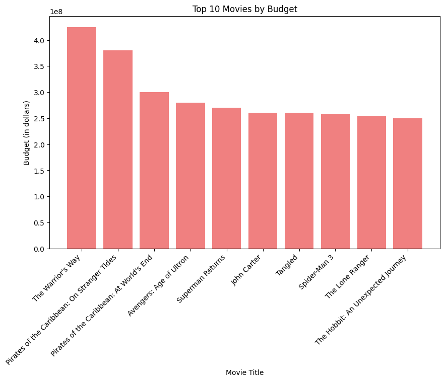

```python
plot_top10(top_budget_movies, 'original_title', 'budget',
           'Top 10 Movies by Budget', 'Movie Title', 'Budget (in dollars)', color='lightcoral')
```

### Research Question 2: Which Movies Received the Most Votes from Viewers?

To find the movies with the most viewer engagement, we sorted the dataset by the `vote_count` column in descending order. This helped us identify the movies with the highest number of votes, showing which movies generated the most interest from audiences.

**Sort the Movies by vote count**

```python
# Sort movies by vote count in descending order and display the top 10
top_voted_movies = df.sort_values(by='vote_count', ascending=False).head(10)
top_voted_movies[['original_title', 'vote_count']]
```

|  | original_title | vote_count |
| --- | --- | --- |
| 1919 | Inception | 9767 |
| 4361 | The Avengers | 8903 |
| 1386 | Avatar | 8458 |
| 2875 | The Dark Knight | 8432 |
| 4364 | Django Unchained | 7375 |
| 4382 | The Hunger Games | 7080 |
| 5425 | Iron Man 3 | 6882 |
| 4363 | The Dark Knight Rises | 6723 |
| 629 | Interstellar | 6498 |
| 4367 | The Hobbit: An Unexpected Journey | 6417 |

The table above lists the top 10 movies with the highest vote counts. These are the movies that received the most viewer votes, indicating they were widely discussed and popular.

**The Visualization (Plot)**

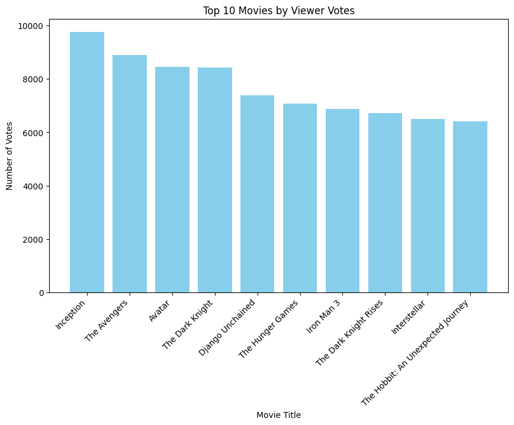

```python
plot_top10(top_voted_movies, 'original_title', 'vote_count',
           'Top 10 Movies by Viewer Votes', 'Movie Title', 'Number of Votes', color='skyblue')
```

### Research Question 3: What is the Average Rating for Movies in Each Genre?

To find the average rating for each genre, we:

1. Split the `genres` column (since some movies have multiple genres).
2. Calculated the average `vote_average` for each genre.

```python
# Remove rows with missing genres and split genres
df_genres = df.dropna(subset=['genres'])
df_genres['genres'] = df_genres['genres'].str.split('|')
df_genres = df_genres.explode('genres')

# Calculate average rating by genre
average_rating_by_genre = df_genres.groupby('genres')['vote_average'].mean()
average_rating_by_genre
```

```
genres
Action             5.787752
Adventure          5.940585
Animation          6.403147
Comedy             5.905167
Crime              6.124889
Documentary        6.908462
Drama              6.165546
Family             5.997563
Fantasy            5.863537
Foreign            5.981383
History            6.410479
Horror             5.337447
Music              6.480392
Mystery            5.946790
Romance            6.042874
Science Fiction    5.665582
TV Movie           5.788024
Thriller           5.750671
Unknown            6.421739
War                6.297778
Western            6.083030
Name: vote_average, dtype: float64
```

The table above shows the average rating for each genre, it help us to see which genres tend to have higher viewer ratings.

**The Visualization (Plot)**

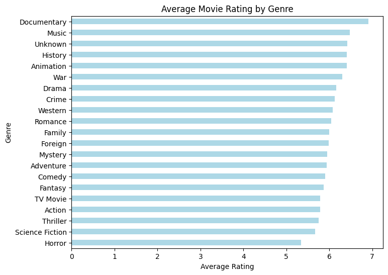

```python
# Plot average rating by genre with a horizontal bar plot
plt.figure(figsize=(8, 6))
average_rating_by_genre.sort_values().plot(kind='barh', color='lightblue')
plt.title('Average Movie Rating by Genre')
plt.xlabel('Average Rating')
plt.ylabel('Genre')
plt.show()
```

### Research Question 4: Is the Budget Related to a Higher Average Vote?

To see if there’s a relation between a movie’s budget and its average viewer rating, we’ll calculate the correlation between the `budget` and `vote_average` columns. A positive correlation would mean that higher budgets tend to result in higher ratings, while a negative correlation would suggest the opposite.

- If the correlation value is close to 1, it means there’s a strong positive relationship (higher budgets might lead to higher ratings).
- If it’s close to -1, it means there’s a strong negative relationship.
- If it’s near 0, it suggests no strong connection between budget and ratings.

```python
# Calculate correlation between budget and average vote
budget_vote_correlation = df[['budget', 'vote_average']].corr().iloc[0, 1]
print(f"Correlation between budget and average vote is: {budget_vote_correlation}")
```

```
Correlation between budget and average vote is: 0.08106672575599086
```

The correlation value is close to zero, which suggests that there is no strong relationship between a movie's budget and its average viewer rating.

**The Visualization (Plot)**

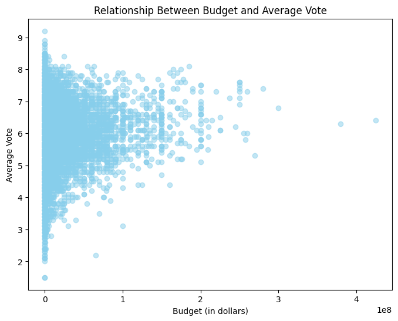

```python
# Scatter plot of budget vs. average vote
plt.figure(figsize=(8, 6))
plt.scatter(df['budget'], df['vote_average'], alpha=0.5, color='skyblue')
plt.title('Relationship Between Budget and Average Vote')
plt.xlabel('Budget (in dollars)')
plt.ylabel('Average Vote')
plt.show()
```

### Research Question 5: What Are the Most Common Release Years in the Dataset?

To find the years with the most movie releases, we counted the number of movies released each year and sorted the results in descending order.

```python
# Count the number of movies released each year
release_year_counts = df['release_year'].value_counts()

# Sort the counts in descending order to get the most common release years
release_year_counts = release_year_counts.sort_values(ascending=False)

# Display the top 10 most common release years
release_year_counts.head(10)
```

```
2014    700
2013    659
2015    629
2012    588
2011    540
2009    533
2008    496
2010    489
2007    438
2006    408
Name: release_year, dtype: int64
```

The table below shows the top 10 most common release years, highlighting the years with the highest number of movie releases. This gives us a quick view of the most active years in movie production within the dataset.

**The Visualization (Plot)**

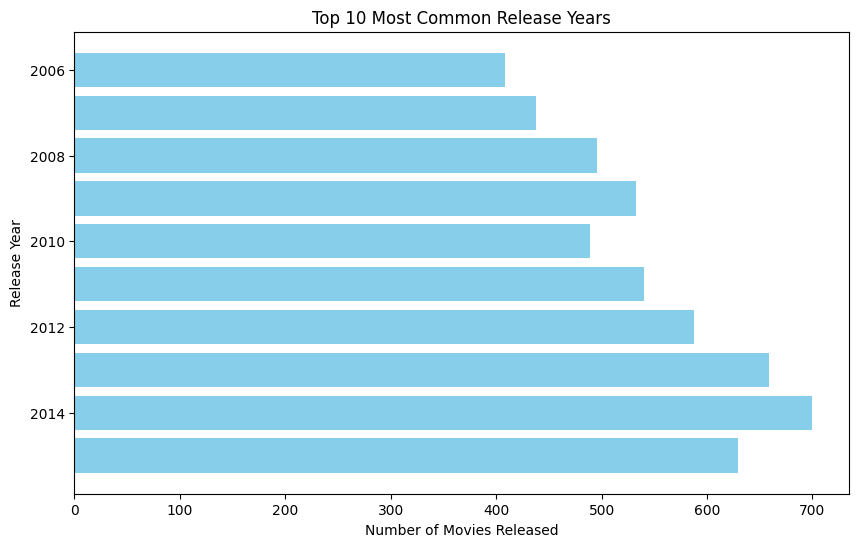

```python
plot_top10(release_year_counts.head(10).reset_index(), 'index', 'release_year',
           'Top 10 Most Common Release Years', 'Number of Movies Released', 'Release Year',
           color='skyblue', horizontal=True)
```

### Research Question 6: Is There a Relationship Between Movie Popularity and Revenue?

before ploting,I display a small sample of the data to get a feel for the popularity and revenue values.

```python
# Display a sample table of popularity and adjusted revenue columns
popularity_revenue_sample = df[['popularity', 'revenue_adj']].sample(10)
popularity_revenue_sample
```

|  | popularity | revenue_adj |
| --- | --- | --- |
| 3253 | 0.176665 | 0.000000e+00 |
| 7822 | 0.010471 | 0.000000e+00 |
| 1890 | 0.086490 | 0.000000e+00 |
| 8923 | 0.391453 | 0.000000e+00 |
| 2200 | 0.319013 | 0.000000e+00 |
| 7284 | 0.321141 | 4.409595e+08 |
| 5833 | 0.238632 | 1.420833e+07 |
| 7907 | 0.633247 | 8.067867e+07 |
| 8879 | 0.035184 | 0.000000e+00 |
| 2292 | 0.200531 | 0.000000e+00 |

**The Visualization (Plot)**

Now, we’ll create a scatter chart to see if there’s a pattern between popularity and revenue.

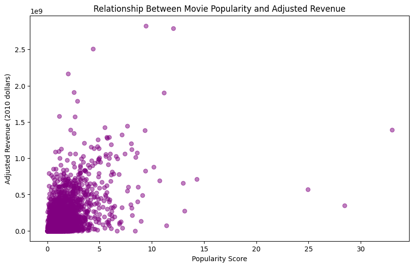

```python
# Scatter plot of popularity vs. adjusted revenue
plt.figure(figsize=(10, 6))
plt.scatter(df['popularity'], df['revenue_adj'], alpha=0.5, color='purple')
plt.title('Relationship Between Movie Popularity and Adjusted Revenue')
plt.xlabel('Popularity Score')
plt.ylabel('Adjusted Revenue (2010 dollars)')
plt.show()
```

The scatter plot shows that most movies have low popularity and lower revenue (clustered in the bottom-left). Some highly popular movies earn much higher revenue, but there’s no clear pattern—popularity doesn’t strongly predict revenue. This suggests other factors likely influence a movie’s earnings.

### Research Question 7: How Has the Average Budget for Movies Changed Over the Years?

To explore how movie production budgets have changed over time, we calculated the average `budget` for each release year and plotted it on a line chart. This helps us see if studios have been spending more or less on making movies over the years.

```python
# Calculate the average budget for each release year
average_budget_by_year = df.groupby('release_year')['budget'].mean()
# Print the average budget by year
print("Average Movie Budget by Release Year:")
print(average_budget_by_year)
```

```
Average Movie Budget by Release Year:
release_year
1960    6.892796e+05
1961    1.488290e+06
1962    1.710066e+06
1963    2.156809e+06
1964    9.400753e+05
1965    2.005860e+06
1966    1.251191e+06
1967    2.516305e+06
1968    1.844590e+06
1969    1.359003e+06
1970    3.096755e+06
1971    1.381764e+06
1972    9.069813e+05
```

[output cut: 44 more lines]

**The Visualization (Plot)**

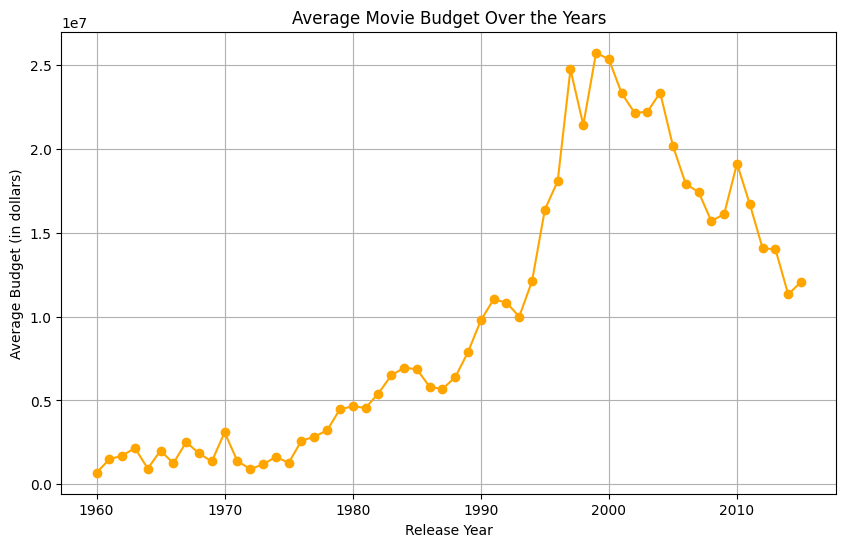

```python
# Plot the average movie budget over the years as a line chart
import matplotlib.pyplot as plt

plt.figure(figsize=(10, 6))
average_budget_by_year.plot(kind='line', color='orange', marker='o')
plt.title('Average Movie Budget Over the Years')
plt.xlabel('Release Year')
plt.ylabel('Average Budget (in dollars)')
plt.grid(True)
plt.show()
```

### Research Question 8: Which Movies Have the Highest Revenue, Adjusted for Inflation?

To find the movies with the highest revenue adjusted for inflation, we used the `revenue_adj` column. This column provides the revenue adjusted to 2010 dollars, allowing for a fair comparison across movies released in different years.

```python
top_revenue_movies = df.sort_values(by='revenue_adj', ascending=False).head(10)
print("Top 10 Movies by Adjusted Revenue:")
print(top_revenue_movies[['original_title', 'revenue_adj']])
```

```
Top 10 Movies by Adjusted Revenue:
                       original_title   revenue_adj
1386                           Avatar  2.827124e+09
1329                        Star Wars  2.789712e+09
5231                          Titanic  2.506406e+09
10594                    The Exorcist  2.167325e+09
9806                             Jaws  1.907006e+09
3        Star Wars: The Force Awakens  1.902723e+09
8889       E.T. the Extra-Terrestrial  1.791694e+09
8094                          The Net  1.583050e+09
10110  One Hundred and One Dalmatians  1.574815e+09
4361                     The Avengers  1.443191e+09
```

The table below lists the top 10 movies with the highest adjusted revenue, showing which movies achieved the most financial success.

**The Visualization (Plot)**

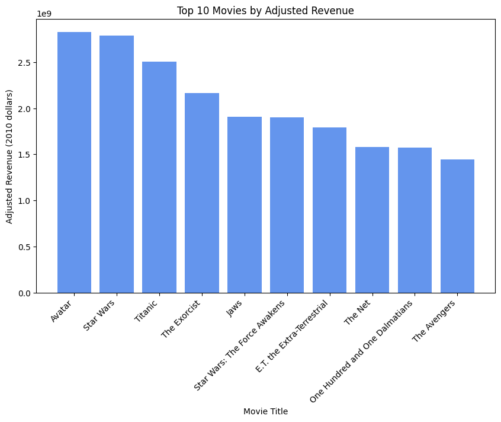

```python
plot_top10(top_revenue_movies.set_index('original_title').reset_index(), 'original_title', 'revenue_adj',
           'Top 10 Movies by Adjusted Revenue', 'Movie Title', 'Adjusted Revenue (2010 dollars)',
           color='cornflowerblue')
```

### Research Question 9: What is the Average Runtime for Movies in Each Genre?

I calculated the average `runtime` for each `genreTo` to see if some genres tend to have longer or shorter movies. This can reveal whether genres like drama or action are generally longer, while genres like comedy might be shorter.

```python
# Split genres and calculate average runtime for each genre
df_genres = df.dropna(subset=['genres'])  # Remove rows with missing genres
df_genres['genres'] = df_genres['genres'].str.split('|')
df_genres = df_genres.explode('genres')

# Calculate the average runtime by genre
average_runtime_by_genre = df_genres.groupby('genres')['runtime'].mean().sort_values(ascending=False)
print("Average Runtime by Genre:")
print(average_runtime_by_genre.head(10))
```

```
Average Runtime by Genre:
genres
History      136.206587
War          127.625926
Western      117.575758
Drama        110.478151
Foreign      107.228723
Crime        106.917282
Romance      106.891355
Adventure    106.173351
Mystery      105.928395
Music        105.137255
Name: runtime, dtype: float64
```

**The Visualization (Plot)**

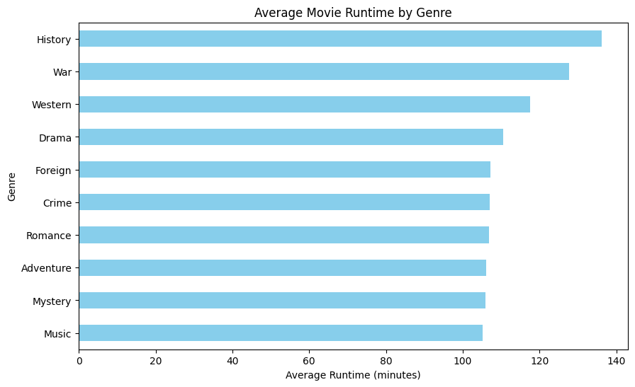

```python
import matplotlib.pyplot as plt

# Plot the average runtime by genre as a horizontal bar plot
plt.figure(figsize=(10, 6))
average_runtime_by_genre.head(10).plot(kind='barh', color='skyblue')
plt.title('Average Movie Runtime by Genre')
plt.xlabel('Average Runtime (minutes)')
plt.ylabel('Genre')
plt.gca().invert_yaxis()  # Show the longest average runtime at the top
plt.show()
```

### Research Question 10: Which Movies Had the Highest Popularity Scores Each Year?

To find out which movies were the most popular each year, we looked at the `popularity` score and selected the top movie for each release year. This gives us a look at the movies that captured the most audience attention annually.

```python
# Find the most popular movie for each year by sorting by popularity within each year
most_popular_movies_by_year = df.loc[df.groupby('release_year')['popularity'].idxmax()][['release_year', 'original_title', 'popularity']]

# Sort by release year in ascending order for a clean display
most_popular_movies_by_year = most_popular_movies_by_year.sort_values(by='release_year', ascending=True)

# Print the table with headers for readability
print("Most Popular Movies by Year:\n")
print(most_popular_movies_by_year.to_string(index=False))
```

```
Most Popular Movies by Year:

 release_year                                    original_title  popularity
         1960                                            Psycho    2.610362
         1961                    One Hundred and One Dalmatians    2.631987
         1962                                            Dr. No    3.170651
         1963                             From Russia With Love    2.508235
         1964                                        Goldfinger    3.153791
         1965                                       Thunderball    1.910465
         1966                   How the Grinch Stole Christmas!    1.227582
         1967                                   The Jungle Book    2.550704
         1968                             2001: A Space Odyssey    3.309196
         1969                   On Her Majesty's Secret Service    1.778746
         1970                                    The Aristocats    1.936962
         1971                                A Clockwork Orange    3.072555
```

[output cut: 44 more lines]

The table above shows the most popular movie from each year, based on its popularity score.

**The Visualization (Plot)**

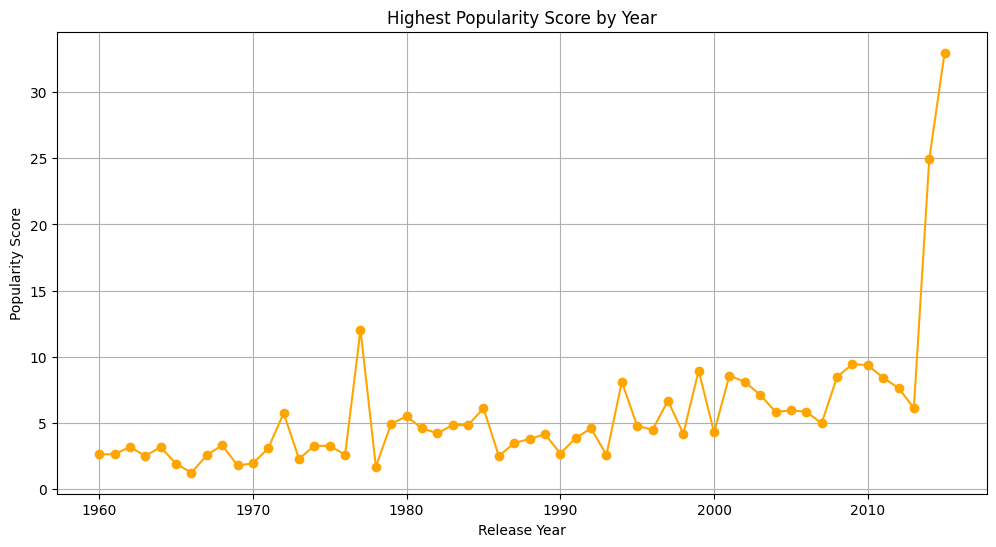

```python
import matplotlib.pyplot as plt

# Plot the most popular movie's popularity score by year
plt.figure(figsize=(12, 6))
plt.plot(most_popular_movies_by_year['release_year'], most_popular_movies_by_year['popularity'], color='orange', marker='o')
plt.title('Highest Popularity Score by Year')
plt.xlabel('Release Year')
plt.ylabel('Popularity Score')
plt.grid(True)
plt.show()
```

### Conclusions

Overall, this analysis helps us understand what makes a movie successful and what audiences enjoy. It also gives insight into how the movie industry has changed over time.

### Limitations

While this analysis offers useful insights, there are some limitations to keep in mind:

1. **Missing Data**: Some columns have missing values, which could slightly impact the accuracy of certain results.
2. **Outdated Financial Adjustments**: Budgets and revenues are adjusted only up to 2010, so the financial data may not fully reflect recent economic changes.
3. **Multiple Genres**: Movies often have more than one genre, which can make it harder to analyze trends specific to a single genre.
4. **Undefined Popularity Metric**: The dataset does not clearly explain how popularity scores are calculated, limiting our understanding of this metric.
5. **Data Up to 2015 Only**: The dataset includes movies only through 2015, so it might not reflect recent trends in the film industry.
6. **Lack of External Factors**: Factors like marketing, global events, or cultural shifts, which can affect a movie’s success, are not included in this data.

These limitations mean that while our findings are insightful, they should be viewed with caution, especially when considering current trends.